## [HOME](http://gzahn.github.io/) | [ABOUT ME](http://gzahn.github.io/about-me/) | [LAB](http://gzahn.github.io/lab/) | [RESEARCH](http://gzahn.github.io/pubs-and-pres/) | [TEACHING](http://gzahn.github.io/coursemap/) | [CV](https://docs.google.com/document/d/1f1DEO7XyHATpOhZWt7Rl-ELzte-SAOTww5uZnUXNTwM/edit?usp=sharing)

[figure not shown]

# **College Biology II**

Utah Valley University - BIOL1620

## Quick links:

#### [Course Syllabus](http://gzahn.github.io/BIOL1620/syllabus.html)

#### [Your-Choice Reading List](https://gzahn.github.io/media/YOUR-CHOICE_Book_List.html)

Audiobooks are only acceptable if they are **unabridged**.

#### [Advice from Former Students](https://github.com/gzahn/Protocols/blob/master/BIOL_1620_Advice_from_Students.pdf)

## Weekly Content:

[figure not shown]

### **Week 1**

**Topics:**

- Early Earth | Evolution | Phylogenies

**Readings and Assignments**

- Campbell Chs 25-26
- Canvas quiz 1 due 11:59pm Friday of the first week (all others due **before** the first class of that week!)
- Pre-Test due Friday 11:59pm
- First assignment (getting to know the course) is due **before our next class.**
- Pick a book to read for Your-Choice Points ASAP
- If you don’t have Campbell Biology yet (for this first week only), here’s a pdf to get you started: [Chapters 25-26](https://gzahn.github.io/media/Campbell_Chs_25-26.pdf)
- **See our Teams page files for more details about the textbook!**

**Resources**

- [Major Topics](https://gzahn.github.io/BIOL1620/mp1.txt)
- Early Earth [Slides](https://github.com/gzahn/BIOL_1620/raw/master/01_First_Day-Early_Earth_and_Syllabus.pdf)
- Antibiotic Resistance [Slides](https://github.com/gzahn/BIOL_1620/raw/master/02_Antibiotic_Resistance.pdf)
- [Rise of Oxygen](https://gzahn.github.io/media/rise_of_oxygen.html)
- [Everything you need to know about reading a phylogeny](https://evolution-outreach.biomedcentral.com/articles/10.1007/s12052-008-0035-x)
- [How to Read Pylogenies (simplistic version)](https://evolution.berkeley.edu/evolibrary/article/_0_0/evo_05)
- [How to Build Phylogenies](https://www.khanacademy.org/science/biology/her/tree-of-life/a/building-an-evolutionary-tree)
- [Mechanisms of Antibiotic Resistance](https://www.ncbi.nlm.nih.gov/pmc/articles/PMC4888801/)

Back to top of page

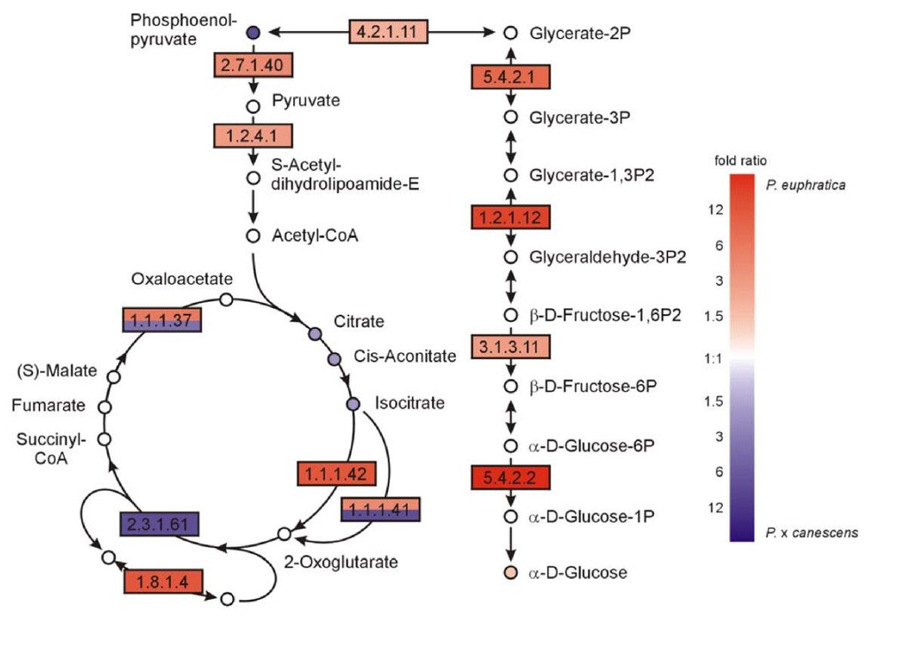

### **Week 2**

**Topics**

- What is life? | Thermodynamics | Major Metabolic Groups | Nature of Science

**Readings and Assignments**

- Good (optional points) Your-Choice book for this would be *Life’s Edge: The Search for What It Means to Be Alive*
- No quiz due this week

**Resources**

- [Major Topics](https://gzahn.github.io/BIOL1620/mp2.txt)
- Survey of Metabolic Groups [Slides](https://github.com/gzahn/BIOL_1620/raw/master/04_TOL_Survey_Metabolism.pdf)
- [Primary Nutritional Groups](https://en.wikipedia.org/wiki/Primary_nutritional_groups)
- What is Life [Online Resource](https://www.khanacademy.org/science/high-school-biology/hs-biology-foundations/hs-biology-and-the-scientific-method/a/what-is-life)
- [The True Meaning of Life](https://www.youtube.com/watch?v=aboZctrHfK8)
- Interesting, if Provocative, [Hypothesis](https://www.scientificamerican.com/article/a-new-physics-theory-of-life/)

Back to top of page

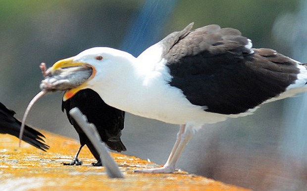

### **Week 3**

**Topics**

- Mechanisms of Evolution | Nature of Science

**Readings and Assignments**

- Campbell Chs 22-23
- Canvas quiz 2 due before our first class this week (see Canvas)

**Resources**

- [Major Topics](https://gzahn.github.io/BIOL1620/mp3.txt)
- Mechanisms of Evolution [Slides](https://github.com/gzahn/BIOL_1620/raw/master/03_Nature_of_Science-Mech_of_Evolution.pdf)
- Mechanisms of Evolution [Website](https://evolution.berkeley.edu/evolibrary/article/evo_14)
- Artificial Selection [Simulation](http://ccl.northwestern.edu/netlogo/models/BirdBreeder)
- Artificial vs Natural Selection [Program](https://www.khanacademy.org/science/ap-biology/natural-selection/artificial-selection/a/evolution-natural-selection-and-human-selection)
- Nature of Science [presentation](https://gzahn.github.io/media/nospresentation72112.pdf)

Back to top of page

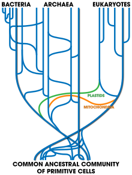

### **Week 4**

**Topics**

- Bacteria and Archaea | Lateral Gene Transfer | Endosymbiosis

**Readings and Assignments**

- Campbell Ch 27
- Canvas quiz 3 due before our first class this week (see Canvas)
- Exam 1 on Friday (closes at 11:59pm)
- 1/4th of the semester as passed, and you need to turn in Your-Choice Points

**Resources**

- [Major Topics](https://gzahn.github.io/BIOL1620/mp4.txt)
- Bacteria and Archaea [Slides](https://github.com/gzahn/BIOL_1620/raw/master/07_Prokaryotes.pdf)
- Lateral Gene Transfer [Between Humans and Microbes](https://www.the-scientist.com/features/bacteria-and-humans-have-been-swapping-dna-for-millennia-32779)
- Primary vs Secondary [Endosymbiosis](https://endosymbiotichypothesis.wordpress.com/primary-versus-secondary-endosymbiosis/)
- *Paulinella* [complicates things](https://www.sciencedirect.com/science/article/pii/S0960982212003077)

Back to top of page

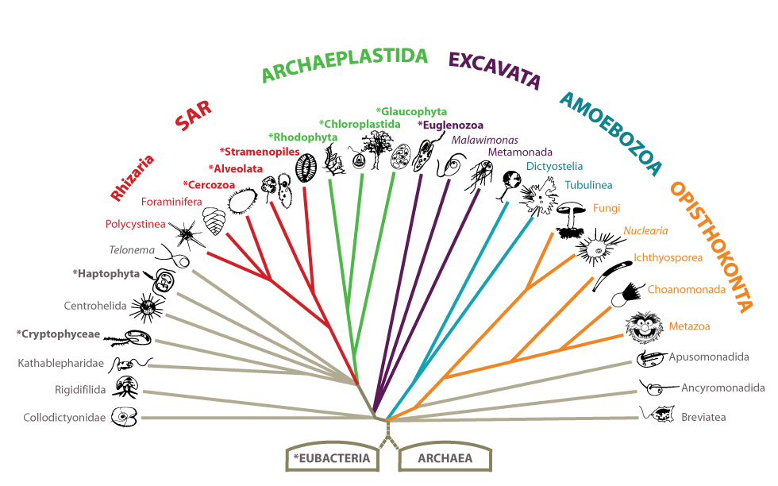

### **Week 5**

**Topics**

- Eukaryotic Supergroups | Overview of “Protists”

**Readings and Assignments**

- Campbell Ch 28
- Canvas quiz 4 due before our first class this week (see Canvas)

**Resources**

- [Major Topics](https://gzahn.github.io/BIOL1620/mp5.txt)
- Protist [Slides](https://github.com/gzahn/BIOL_1620/raw/master/08_Protist_Intro.pdf)
- Revised [Classification of Eukaryotes](https://onlinelibrary.wiley.com/doi/full/10.1111/j.1550-7408.2012.00644.x)
- Why the World Needs [Protists](https://gzahn.github.io/media/corliss2004.pdf)

Back to top of page

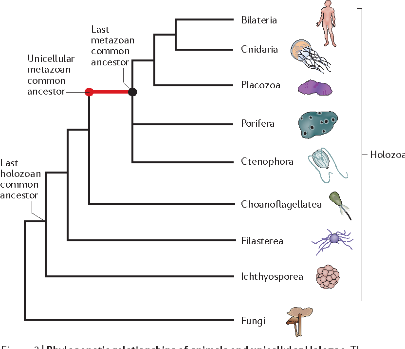

### **Week 6**

**Topics**

- Animals | Defining Traits | Evolution

**Readings and Assignments**

- Campbell Ch 32
- Canvas quiz 5 due before our first class this week (see Canvas)

**Resources**

- [Major Topics](https://gzahn.github.io/BIOL1620/mp6.txt)
- Metazoa [Slides](https://github.com/gzahn/BIOL_1620/raw/master/10_Metazoa_Intro.pdf)
- Metazoa [Brain Teasers](https://github.com/gzahn/BIOL_1620/raw/master/11_Metazoa_First_land_animals_brain_teasers.pdf)
- Animal Evolution [Timeline](https://sci.waikato.ac.nz/evolution/AnimalEvolution.shtml)
- Molecular Clocks and [Early Animal Evolution](https://www.ncbi.nlm.nih.gov/pmc/articles/PMC4650124/)
- Ediacaran [Fossils](https://ucmp.berkeley.edu/vendian/critters.html)
- Cambrian [Fossils](http://www.fossilmuseum.net/Paleobiology/CambrianFossils.htm)
- [Burgess Shale](https://burgess-shale.rom.on.ca/en/science/burgess-shale/03-fossils.php)
- Good [Website](https://www.shapeoflife.org/) on animal groups (Click on “Resources” at the top of the page)

Back to top of page

### **Week 7**

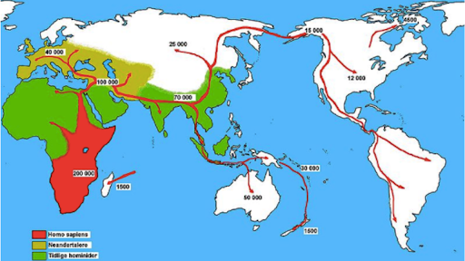

**Topics**

- Invertebrate and Vertebrate Classes | Mammals

**Readings and Assignments**

- Campbell Chs 33-34
- Canvas quiz 6 due before our first class this week (see Canvas)
- Optional Your-Choice Points: Cave of Forgotten Dreams [Video](https://drive.google.com/open?id=1els5LTLnstqsqKFZ-9gm34M8sJtQ3SVZ) goes well with these lessons

**Resources**

- [Major Topics](https://gzahn.github.io/BIOL1620/mp7.txt)
- Invertebrate [Slides](https://github.com/gzahn/BIOL_1620/raw/master/12_Invertebrates.pdf)
- Vertebrate [Slides](https://github.com/gzahn/BIOL_1620/raw/master/13_Vertebrates.pdf)
- Mammals, Primates, Hominins [Slides](https://github.com/gzahn/BIOL_1620/raw/master/14_Mammals_Primates_Hominins.pdf)
- Human Evolution [Timeline](http://humanorigins.si.edu/evidence/human-evolution-timeline-interactive)
- Animal [Phyla](http://www.fossilmuseum.net/Tree_of_Life/Kingdom_animalia/animalphyla.htm)

Back to top of page

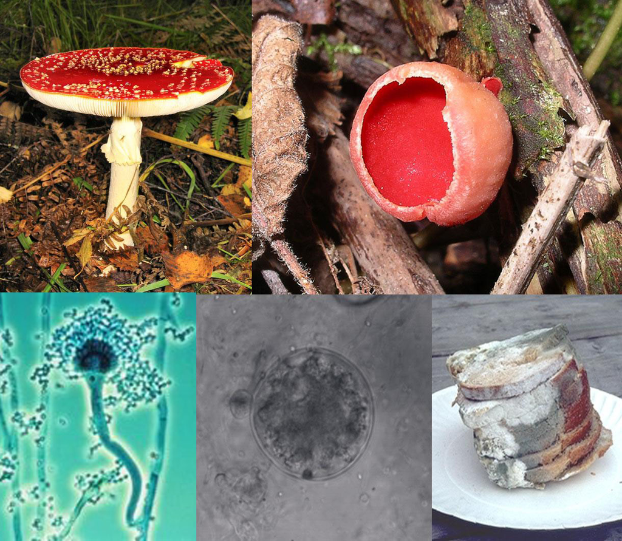

### **Week 8**

**Topics**

- Fungi

**Readings and Assignments**

- Campbell Ch 31
- Canvas quiz 7 due before our first class this week (see Canvas)
- Exam 2 due Friday (closes 11:59pm)
- 50 Your-Choice Points Due Friday 11:59pm

**Resources**

- [Major Topics](https://gzahn.github.io/BIOL1620/mp8.txt)
- Fungus [Slides](https://github.com/gzahn/BIOL_1620/raw/master/15_Fungi_Intro.pdf)
- Common Ancestor of Animals and [Fungi](https://gzahn@github.io/media/2881059.pdf)
- Fungal [Phyla](https://courses.lumenlearning.com/wmopen-biology2/chapter/classifications-of-fungi/)
- Fungal Endophytes and [Your Favorite Professor](https://www.sciencenews.org/article/plant-microbes-crops-food-endangered-species) (Free, but need to enter an email address to subscribe in order to read the article)

Back to top of page

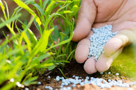

Back to top of page

### **Week 9**

**Topics**

- Plant Nutrition | Soil | GMOs

**Readings and Assignments**

- Make progress on Your-Choice points since there is no reading assignment or quiz this week

**Resources**

- [Major Topics](https://gzahn.github.io/BIOL1620/mp9.txt)
- Plant Nutrition [Slides](https://github.com/gzahn/BIOL_1620/raw/master/17_Plant_Nutrition.pdf)
- GMO [Slides](https://github.com/gzahn/BIOL_1620/raw/master/19_GMOs.pdf)
- GMO Corn [Experiment](https://biofortified.org/experiment/)
- Fake “Science” Version of [Same Experiment](https://non-gmoreport.com/articles/june2013/farmer-experiment-squirrels-prefer-organic-corn.php)
- Glyphosate [MDS](https://alligare.com/wp-content/uploads/2019/06/glyphosate-5.4-sds-v3.1.pdf)
- Evolution of [Plant Carnivory](https://www.nature.com/news/how-plants-evolved-into-carnivores-1.21425)
- Wonderful [documentary](https://www.amazon.com/Plants-Behaving-Badly-Season-1/dp/B071HDHGJ2) from PBS (Need Amazon Prime subscription). Episode 1 is about carnivorous plants. Episode 2 is about orchids.

Back to top of page

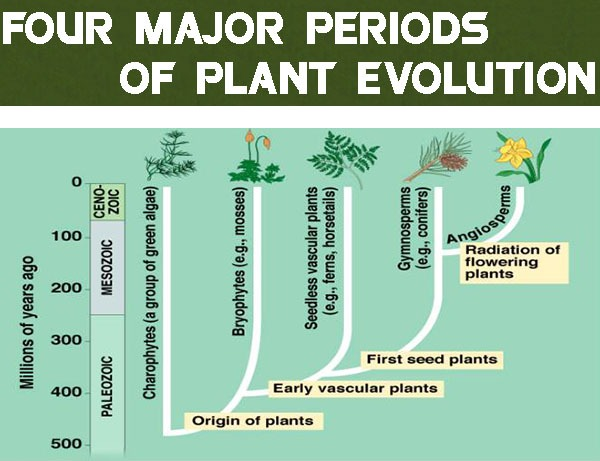

### **Week 10**

**Topics**

- Plant Evolution and Life Cycles

**Readings and Assignments**

- Campbell Chs 29-30
- Canvas quiz 8 due before our first class this week (see Canvas)

**Resources**

- [Major Topics](https://gzahn.github.io/BIOL1620/mp10.txt)
- Plant Evolution [Slides](https://github.com/gzahn/BIOL_1620/raw/master/20_Plant_Evolution.pdf)
- Land Plant Evolution [Timeline](https://www.pnas.org/doi/10.1073/pnas.1719588115)
- Adaptations for Land
- Alternation of Generations [Video](https://study.com/academy/lesson/alternation-of-generations-the-gametophyte-and-sporophyte.html)

Back to top of page

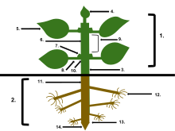

### **Week 11**

**Topics**

- Major Plant Groups | Plant Anatomy

**Readings and Assignments**

- Campbell Chs 35, 37 (optional)
- No quiz over these chapters

**Resources**

- [Major Topics](https://gzahn.github.io/BIOL1620/mp11.txt)
- Seed Plants [Slides](https://github.com/gzahn/BIOL_1620/raw/master/21_Seed_Plants.pdf)
- Plant Anatomy [Slides](https://github.com/gzahn/BIOL_1620/raw/master/22_Plant_Anatomy.pdf)

**Supplemental videos**

- [Seed plants 1](https://youtu.be/iKsntUnAFdw) (What good are seeds?)
- [Seed plants 2](https://youtu.be/XBuOh7j0uLY) (Major gytmnosperm groups)
- [Seed plants 3](https://youtu.be/yFp3D7eU_fs) (Angiosperms)

Back to top of page

[figure not shown]

### **Week 12**

**Topics**

- Animal Behavior

**Assignments**

- Exam 3 Friday (closes at 11:59pm)
- Your-Choice Points are **nearly due**
- Campbell Chs 39, 51 (Optional)
- No quiz over these chapters

**Resources**

- [Major Topics](https://gzahn.github.io/BIOL1620/mp12.txt)
- Animal Behavior [Slides](https://github.com/gzahn/BIOL_1620/raw/master/23_Animal_Behavior.pdf)
- [Superstitious Pigeons](https://www.all-about-psychology.com/support-files/superstition-in-the-pigeon.pdf)
- Evolutionary Selection for [Superstition](https://www.ncbi.nlm.nih.gov/pmc/articles/PMC2615824/)
- Classical vs Operant [Conditioning](https://www.khanacademy.org/test-prep/mcat/behavior/learning-slug/a/classical-and-operant-conditioning-article)
- Cuckoo Bird [Gentees](https://cpb-us-w2.wpmucdn.com/u.osu.edu/dist/3/39517/files/2015/09/35025058-14uu57d.pdf)

**Supplemental videos**

- [Animal Behavior 1](https://www.youtube.com/watch?v=jqlJdyONbYc&t=18s)
- [Animal Behavior 2](https://www.youtube.com/watch?v=IwnXupjOKxE)
- [Animal Behavior 3](https://www.youtube.com/watch?v=ai6MSqFHiHg)

Back to top of page

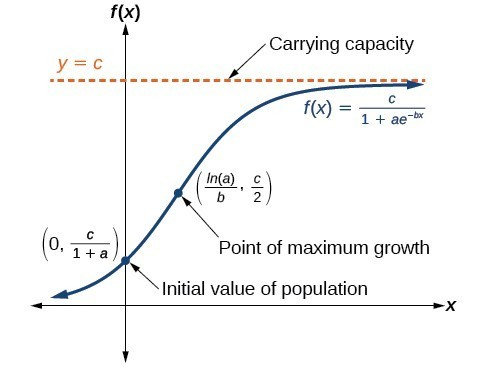

### **Week 13**

**Topics**

- Population Ecology

**Readings and Assignments**

- Campbell Chs 52, 53
- Canvas quiz 9 due before our first class this week (see Canvas)

**Resources**

- [Major Topics](https://gzahn.github.io/BIOL1620/mp13.txt)
- Population Ecology [Slides](https://github.com/gzahn/BIOL_1620/raw/master/24_Ecology_Intro_and_PopEcol.pdf)
- Logistic Growth [Model](https://www.biointeractive.org/classroom-resources/population-dynamics)
- Population [Genomics](https://www.nature.com/scitable/knowledge/library/population-genomics-15812442/)
- Population Genetics and [Neanderthals](https://www.genomeweb.com/sequencing/neanderthal-population-dynamics-clarified-new-sequence-data)
- More [Amazing Neanderthal Stuff](https://www.ncbi.nlm.nih.gov/pmc/articles/PMC5772775/)
- Earth’s [historical climate](https://xkcd.com/1732/) cartoon
- IPCC [AR5 Synthesis Report](https://www.ipcc.ch/site/assets/uploads/2018/02/SYR_AR5_FINAL_full.pdf)
- IPCC [Physical Sciences Basis](https://www.ipcc.ch/site/assets/uploads/2018/02/WG1AR5_all_final.pdf) Report - Evidence for anthropogenic climate change

**Supplemental videos**

- [Ecology Intro 1](https://www.youtube.com/watch?v=YZmmx_fWQfo) - Levels of scale
- [Ecology Intro 2](https://www.youtube.com/watch?v=oU7xCrTfs2s) - Climate modeling

Back to top of page

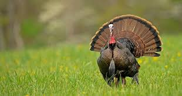

### **Week 14**

**Thanksgiving Break**

**Final Your-Choice Points Due Friday 11:59pm**

You’ve had all semester and at the end of Thanksgiving Break, all those assignments are due. I’ll start grading over the weekend, but it will take me a while since most of you will have waited until the last possible minute to turn them in.

Back to top of page

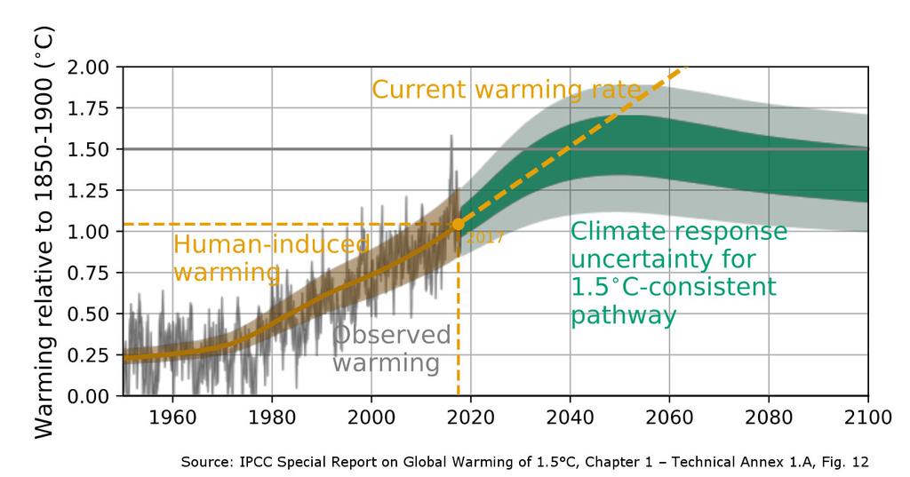

### **Week 15**

**Topics**

- Community Ecology | BioGeoChemistry

**Readings and Assignments**

- Campbell Chs 54-55
- Canvas quiz 10 due before our first class this week (see Canvas) (This quiz is open for all of Thanksgiving Break)

**Resources**

- [Major Topics](https://gzahn.github.io/BIOL1620/mp14.txt)
- Community Ecology [Slides](https://github.com/gzahn/BIOL_1620/raw/master/25_Community_Ecology.pdf)
- Analyze Metagenomes Yourself! With [This Website](https://www.mg-rast.org/mgmain.html?mgpage=analysis)
- Sea Ice [Video](https://gzahn.github.io/media/SeaIce.mp4)
- IPCC AR5 [Report](https://www.ipcc.ch/site/assets/uploads/2018/02/SYR_AR5_FINAL_full.pdf) Read it and weep.
- Modeling Trout [Extinction Risk](https://trout.shinyapps.io/lahontan/)

Back to top of page

[figure not shown]

### **Week 16**

**Topics**

- Wrap-up | Gaia Hypothesis | What is Life?

**Readings and Assignments**

- Post-Test due Friday (closes at 11:59pm)
- If you haven’t turned in Your-Choice Points yet, you’ve missed your chance
- Also, if that’s the case, you had your chance so no whining

**Resources**

- Daisyball [Simulation](http://www.gingerbooth.com/flash/daisyball/DaisyBall.html)
- [Gaia hypothesis](https://courses.seas.harvard.edu/climate/eli/Courses/EPS281r/Sources/Gaia/Gaia-hypothesis-wikipedia.pdf)

Back to top of page